# Risk Factor Analysis

## Outcome Variable

**Outcome Variable:** whz

## Predictor Variables

**Intervention Variable:** predfeed6

**Adjustment Set:**

- arm
- sex
- month
- brthmon
- W_mage
- meducyrs
- feducyrs
- hhwealth_quart
- hfoodsec
- W_mhtcm
- W_mwtkg
- W_mbmi
- vagbrth
- W_gagebrth
- W_birthwt
- W_birthlen
- W_nrooms
- W_nchldlt5
- W_parity
- impfloor
- impsan
- safeh20
- delta_W_mage
- delta_meducyrs
- delta_feducyrs
- delta_hhwealth_quart
- delta_hfoodsec
- delta_W_mhtcm
- delta_W_mwtkg
- delta_W_mbmi
- delta_vagbrth
- delta_W_gagebrth
- delta_W_birthwt
- delta_W_birthlen
- delta_W_nrooms
- delta_W_nchldlt5
- delta_W_parity
- delta_impfloor
- delta_impsan
- delta_safeh20

## Stratifying Variables

The analysis was stratified on these variable(s):

- agecat
- studyid
- country

## Data Summary

| agecat | studyid | country | predfeed6 | n_cell | n | outcome_variable |
| --- | --- | --- | --- | --- | --- | --- |
| Birth | ki0047075b-MAL-ED | BANGLADESH | 1 | 68 | 194 | whz |
| Birth | ki0047075b-MAL-ED | BANGLADESH | 0 | 126 | 194 | whz |
| Birth | ki0047075b-MAL-ED | BRAZIL | 1 | 5 | 57 | whz |
| Birth | ki0047075b-MAL-ED | BRAZIL | 0 | 52 | 57 | whz |
| Birth | ki0047075b-MAL-ED | INDIA | 1 | 4 | 37 | whz |
| Birth | ki0047075b-MAL-ED | INDIA | 0 | 33 | 37 | whz |
| Birth | ki0047075b-MAL-ED | NEPAL | 1 | 3 | 23 | whz |
| Birth | ki0047075b-MAL-ED | NEPAL | 0 | 20 | 23 | whz |
| Birth | ki0047075b-MAL-ED | PERU | 1 | 72 | 208 | whz |
| Birth | ki0047075b-MAL-ED | PERU | 0 | 136 | 208 | whz |
| Birth | ki0047075b-MAL-ED | SOUTH AFRICA | 1 | 1 | 90 | whz |
| Birth | ki0047075b-MAL-ED | SOUTH AFRICA | 0 | 89 | 90 | whz |
| Birth | ki0047075b-MAL-ED | TANZANIA, UNITED REPUBLIC OF | 1 | 0 | 105 | whz |
| Birth | ki0047075b-MAL-ED | TANZANIA, UNITED REPUBLIC OF | 0 | 105 | 105 | whz |
| Birth | ki1000109-EE | PAKISTAN | 1 | 24 | 28 | whz |
| Birth | ki1000109-EE | PAKISTAN | 0 | 4 | 28 | whz |
| Birth | ki1113344-GMS-Nepal | NEPAL | 1 | 390 | 522 | whz |
| Birth | ki1113344-GMS-Nepal | NEPAL | 0 | 132 | 522 | whz |
| Birth | kiGH5241-JiVitA-3 | BANGLADESH | 1 | 8392 | 10744 | whz |
| Birth | kiGH5241-JiVitA-3 | BANGLADESH | 0 | 2352 | 10744 | whz |
| Birth | kiGH5241-JiVitA-4 | BANGLADESH | 1 | 1802 | 2224 | whz |
| Birth | kiGH5241-JiVitA-4 | BANGLADESH | 0 | 422 | 2224 | whz |
| 6 months | ki0047075b-MAL-ED | BANGLADESH | 1 | 84 | 231 | whz |
| 6 months | ki0047075b-MAL-ED | BANGLADESH | 0 | 147 | 231 | whz |
| 6 months | ki0047075b-MAL-ED | BRAZIL | 1 | 30 | 209 | whz |
| 6 months | ki0047075b-MAL-ED | BRAZIL | 0 | 179 | 209 | whz |
| 6 months | ki0047075b-MAL-ED | INDIA | 1 | 11 | 218 | whz |
| 6 months | ki0047075b-MAL-ED | INDIA | 0 | 207 | 218 | whz |
| 6 months | ki0047075b-MAL-ED | NEPAL | 1 | 12 | 225 | whz |
| 6 months | ki0047075b-MAL-ED | NEPAL | 0 | 213 | 225 | whz |
| 6 months | ki0047075b-MAL-ED | PERU | 1 | 92 | 271 | whz |
| 6 months | ki0047075b-MAL-ED | PERU | 0 | 179 | 271 | whz |
| 6 months | ki0047075b-MAL-ED | SOUTH AFRICA | 1 | 3 | 233 | whz |
| 6 months | ki0047075b-MAL-ED | SOUTH AFRICA | 0 | 230 | 233 | whz |
| 6 months | ki0047075b-MAL-ED | TANZANIA, UNITED REPUBLIC OF | 1 | 1 | 232 | whz |
| 6 months | ki0047075b-MAL-ED | TANZANIA, UNITED REPUBLIC OF | 0 | 231 | 232 | whz |
| 6 months | ki1000109-EE | PAKISTAN | 1 | 43 | 48 | whz |
| 6 months | ki1000109-EE | PAKISTAN | 0 | 5 | 48 | whz |
| 6 months | ki1000304b-SAS-FoodSuppl | INDIA | 1 | 0 | 168 | whz |
| 6 months | ki1000304b-SAS-FoodSuppl | INDIA | 0 | 168 | 168 | whz |
| 6 months | ki1113344-GMS-Nepal | NEPAL | 1 | 406 | 547 | whz |
| 6 months | ki1113344-GMS-Nepal | NEPAL | 0 | 141 | 547 | whz |
| 6 months | ki1148112-LCNI-5 | MALAWI | 1 | 47 | 272 | whz |
| 6 months | ki1148112-LCNI-5 | MALAWI | 0 | 225 | 272 | whz |
| 6 months | kiGH5241-JiVitA-3 | BANGLADESH | 1 | 7625 | 9882 | whz |
| 6 months | kiGH5241-JiVitA-3 | BANGLADESH | 0 | 2257 | 9882 | whz |
| 6 months | kiGH5241-JiVitA-4 | BANGLADESH | 1 | 3327 | 4275 | whz |
| 6 months | kiGH5241-JiVitA-4 | BANGLADESH | 0 | 948 | 4275 | whz |
| 24 months | ki0047075b-MAL-ED | BANGLADESH | 1 | 76 | 205 | whz |
| 24 months | ki0047075b-MAL-ED | BANGLADESH | 0 | 129 | 205 | whz |
| 24 months | ki0047075b-MAL-ED | BRAZIL | 1 | 25 | 169 | whz |
| 24 months | ki0047075b-MAL-ED | BRAZIL | 0 | 144 | 169 | whz |
| 24 months | ki0047075b-MAL-ED | INDIA | 1 | 11 | 209 | whz |
| 24 months | ki0047075b-MAL-ED | INDIA | 0 | 198 | 209 | whz |
| 24 months | ki0047075b-MAL-ED | NEPAL | 1 | 12 | 219 | whz |
| 24 months | ki0047075b-MAL-ED | NEPAL | 0 | 207 | 219 | whz |
| 24 months | ki0047075b-MAL-ED | PERU | 1 | 68 | 201 | whz |
| 24 months | ki0047075b-MAL-ED | PERU | 0 | 133 | 201 | whz |
| 24 months | ki0047075b-MAL-ED | SOUTH AFRICA | 1 | 3 | 216 | whz |
| 24 months | ki0047075b-MAL-ED | SOUTH AFRICA | 0 | 213 | 216 | whz |
| 24 months | ki0047075b-MAL-ED | TANZANIA, UNITED REPUBLIC OF | 1 | 1 | 202 | whz |
| 24 months | ki0047075b-MAL-ED | TANZANIA, UNITED REPUBLIC OF | 0 | 201 | 202 | whz |
| 24 months | ki1000109-EE | PAKISTAN | 1 | 20 | 23 | whz |
| 24 months | ki1000109-EE | PAKISTAN | 0 | 3 | 23 | whz |
| 24 months | ki1113344-GMS-Nepal | NEPAL | 1 | 355 | 469 | whz |
| 24 months | ki1113344-GMS-Nepal | NEPAL | 0 | 114 | 469 | whz |
| 24 months | ki1148112-LCNI-5 | MALAWI | 1 | 34 | 184 | whz |
| 24 months | ki1148112-LCNI-5 | MALAWI | 0 | 150 | 184 | whz |
| 24 months | kiGH5241-JiVitA-3 | BANGLADESH | 1 | 3909 | 5067 | whz |
| 24 months | kiGH5241-JiVitA-3 | BANGLADESH | 0 | 1158 | 5067 | whz |
| 24 months | kiGH5241-JiVitA-4 | BANGLADESH | 1 | 3278 | 4184 | whz |
| 24 months | kiGH5241-JiVitA-4 | BANGLADESH | 0 | 906 | 4184 | whz |

The following strata were considered:

- agecat: 24 months, studyid: ki0047075b-MAL-ED, country: BANGLADESH
- agecat: 24 months, studyid: ki0047075b-MAL-ED, country: BRAZIL
- agecat: 24 months, studyid: ki0047075b-MAL-ED, country: INDIA
- agecat: 24 months, studyid: ki0047075b-MAL-ED, country: NEPAL
- agecat: 24 months, studyid: ki0047075b-MAL-ED, country: PERU
- agecat: 24 months, studyid: ki0047075b-MAL-ED, country: SOUTH AFRICA
- agecat: 24 months, studyid: ki0047075b-MAL-ED, country: TANZANIA, UNITED REPUBLIC OF
- agecat: 24 months, studyid: ki1000109-EE, country: PAKISTAN
- agecat: 24 months, studyid: ki1113344-GMS-Nepal, country: NEPAL
- agecat: 24 months, studyid: ki1148112-LCNI-5, country: MALAWI
- agecat: 24 months, studyid: kiGH5241-JiVitA-3, country: BANGLADESH
- agecat: 24 months, studyid: kiGH5241-JiVitA-4, country: BANGLADESH
- agecat: 6 months, studyid: ki0047075b-MAL-ED, country: BANGLADESH
- agecat: 6 months, studyid: ki0047075b-MAL-ED, country: BRAZIL
- agecat: 6 months, studyid: ki0047075b-MAL-ED, country: INDIA
- agecat: 6 months, studyid: ki0047075b-MAL-ED, country: NEPAL
- agecat: 6 months, studyid: ki0047075b-MAL-ED, country: PERU
- agecat: 6 months, studyid: ki0047075b-MAL-ED, country: SOUTH AFRICA
- agecat: 6 months, studyid: ki0047075b-MAL-ED, country: TANZANIA, UNITED REPUBLIC OF
- agecat: 6 months, studyid: ki1000109-EE, country: PAKISTAN
- agecat: 6 months, studyid: ki1000304b-SAS-FoodSuppl, country: INDIA
- agecat: 6 months, studyid: ki1113344-GMS-Nepal, country: NEPAL
- agecat: 6 months, studyid: ki1148112-LCNI-5, country: MALAWI
- agecat: 6 months, studyid: kiGH5241-JiVitA-3, country: BANGLADESH
- agecat: 6 months, studyid: kiGH5241-JiVitA-4, country: BANGLADESH
- agecat: Birth, studyid: ki0047075b-MAL-ED, country: BANGLADESH
- agecat: Birth, studyid: ki0047075b-MAL-ED, country: BRAZIL
- agecat: Birth, studyid: ki0047075b-MAL-ED, country: INDIA
- agecat: Birth, studyid: ki0047075b-MAL-ED, country: NEPAL
- agecat: Birth, studyid: ki0047075b-MAL-ED, country: PERU
- agecat: Birth, studyid: ki0047075b-MAL-ED, country: SOUTH AFRICA
- agecat: Birth, studyid: ki0047075b-MAL-ED, country: TANZANIA, UNITED REPUBLIC OF
- agecat: Birth, studyid: ki1000109-EE, country: PAKISTAN
- agecat: Birth, studyid: ki1113344-GMS-Nepal, country: NEPAL
- agecat: Birth, studyid: kiGH5241-JiVitA-3, country: BANGLADESH
- agecat: Birth, studyid: kiGH5241-JiVitA-4, country: BANGLADESH

### Dropped Strata

Some strata were dropped due to rare outcomes:

- agecat: Birth, studyid: ki0047075b-MAL-ED, country: INDIA
- agecat: Birth, studyid: ki0047075b-MAL-ED, country: NEPAL
- agecat: Birth, studyid: ki0047075b-MAL-ED, country: SOUTH AFRICA
- agecat: Birth, studyid: ki0047075b-MAL-ED, country: TANZANIA, UNITED REPUBLIC OF
- agecat: Birth, studyid: ki1000109-EE, country: PAKISTAN
- agecat: 6 months, studyid: ki0047075b-MAL-ED, country: SOUTH AFRICA
- agecat: 6 months, studyid: ki0047075b-MAL-ED, country: TANZANIA, UNITED REPUBLIC OF
- agecat: 6 months, studyid: ki1000304b-SAS-FoodSuppl, country: INDIA
- agecat: 24 months, studyid: ki0047075b-MAL-ED, country: SOUTH AFRICA
- agecat: 24 months, studyid: ki0047075b-MAL-ED, country: TANZANIA, UNITED REPUBLIC OF
- agecat: 24 months, studyid: ki1000109-EE, country: PAKISTAN

## Methods Detail

We’re interested in the causal parameters $E[Y_a]$ for all values of $a \in \mathcal{A}$. These parameters represent the mean outcome if, possibly contrary to fact, we intervened to set all units to have $A=a$. Under the randomization and positivity assumptions, these are identified by the statistical parameters $\psi_a=E_W[E_{Y|A,W}(Y|A=a,W)]$. In addition, we’re interested in the mean of $Y$, $E[Y]$ under no intervention (the observed mean). We will estimate these parameters by using SuperLearner to fit the relevant likelihood factors – $E_{Y|A,W}(Y|A=a,W)$ and $p(A=a|W)$, and then updating our likelihood fit using a joint TMLE.

For unadjusted analyses ($W=\{\}$), initial likelihoods were estimated using Lrnr_glm to estimate the simple $E(Y|A)$ and Lrnr_mean to estimate $p(A)$. For adjusted analyses, a small library containing Lrnr_glmnet, Lrnr_xgboost, and Lrnr_mean was used.

# Results Detail

## Results Plots

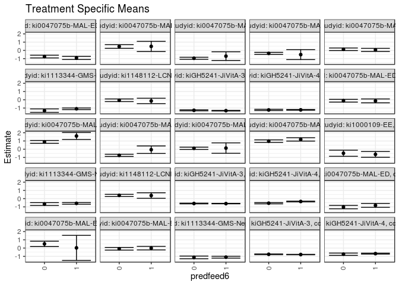

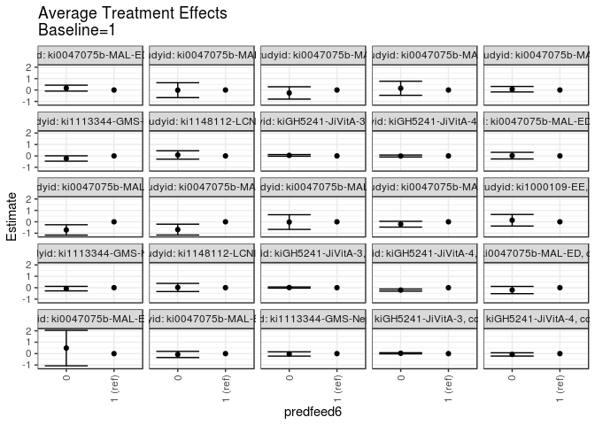

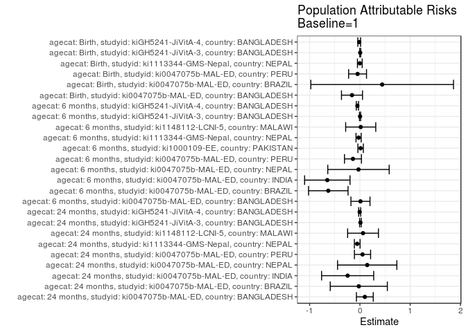

## Results Table

### Parameter: TSM

| agecat | studyid | country | intervention_level | baseline_level | estimate | ci_lower | ci_upper |
| --- | --- | --- | --- | --- | --- | --- | --- |
| Birth | ki0047075b-MAL-ED | BANGLADESH | 1 | NA | -0.8181909 | -1.0525237 | -0.5838581 |
| Birth | ki0047075b-MAL-ED | BANGLADESH | 0 | NA | -1.0238952 | -1.2299396 | -0.8178508 |
| Birth | ki0047075b-MAL-ED | BRAZIL | 1 | NA | 0.0220000 | -1.4978207 | 1.5418207 |
| Birth | ki0047075b-MAL-ED | BRAZIL | 0 | NA | 0.5069231 | 0.1803892 | 0.8334570 |
| Birth | ki0047075b-MAL-ED | PERU | 1 | NA | -0.0123141 | -0.2255487 | 0.2009206 |
| Birth | ki0047075b-MAL-ED | PERU | 0 | NA | -0.0860753 | -0.2501952 | 0.0780446 |
| Birth | ki1113344-GMS-Nepal | NEPAL | 1 | NA | -1.1046281 | -1.2176138 | -0.9916425 |
| Birth | ki1113344-GMS-Nepal | NEPAL | 0 | NA | -1.1353369 | -1.2957967 | -0.9748771 |
| Birth | kiGH5241-JiVitA-3 | BANGLADESH | 1 | NA | -0.7869143 | -0.8117224 | -0.7621061 |
| Birth | kiGH5241-JiVitA-3 | BANGLADESH | 0 | NA | -0.7586814 | -0.8023754 | -0.7149875 |
| Birth | kiGH5241-JiVitA-4 | BANGLADESH | 1 | NA | -0.6764238 | -0.7312515 | -0.6215960 |
| Birth | kiGH5241-JiVitA-4 | BANGLADESH | 0 | NA | -0.7473629 | -0.8846383 | -0.6100875 |
| 6 months | ki0047075b-MAL-ED | BANGLADESH | 1 | NA | -0.1324717 | -0.3688346 | 0.1038912 |
| 6 months | ki0047075b-MAL-ED | BANGLADESH | 0 | NA | -0.1105154 | -0.2775789 | 0.0565482 |
| 6 months | ki0047075b-MAL-ED | BRAZIL | 1 | NA | 1.6007794 | 1.1806161 | 2.0209427 |
| 6 months | ki0047075b-MAL-ED | BRAZIL | 0 | NA | 0.8873063 | 0.7130098 | 1.0616028 |
| 6 months | ki0047075b-MAL-ED | INDIA | 1 | NA | -0.0584892 | -0.5130579 | 0.3960795 |
| 6 months | ki0047075b-MAL-ED | INDIA | 0 | NA | -0.7418050 | -0.8750872 | -0.6085229 |
| 6 months | ki0047075b-MAL-ED | NEPAL | 1 | NA | 0.1375085 | -0.4922755 | 0.7672924 |
| 6 months | ki0047075b-MAL-ED | NEPAL | 0 | NA | 0.1143481 | -0.0244221 | 0.2531183 |
| 6 months | ki0047075b-MAL-ED | PERU | 1 | NA | 1.1890281 | 0.9869039 | 1.3911522 |
| 6 months | ki0047075b-MAL-ED | PERU | 0 | NA | 0.9785631 | 0.8255479 | 1.1315782 |
| 6 months | ki1000109-EE | PAKISTAN | 1 | NA | -0.6248062 | -0.9715960 | -0.2780164 |
| 6 months | ki1000109-EE | PAKISTAN | 0 | NA | -0.4893333 | -0.8590751 | -0.1195916 |
| 6 months | ki1113344-GMS-Nepal | NEPAL | 1 | NA | -0.5749658 | -0.6773721 | -0.4725594 |
| 6 months | ki1113344-GMS-Nepal | NEPAL | 0 | NA | -0.6558214 | -0.8258381 | -0.4858047 |
| 6 months | ki1148112-LCNI-5 | MALAWI | 1 | NA | 0.3764140 | 0.0421624 | 0.7106657 |
| 6 months | ki1148112-LCNI-5 | MALAWI | 0 | NA | 0.3951290 | 0.2681954 | 0.5220626 |
| 6 months | kiGH5241-JiVitA-3 | BANGLADESH | 1 | NA | -0.6033364 | -0.6304499 | -0.5762228 |
| 6 months | kiGH5241-JiVitA-3 | BANGLADESH | 0 | NA | -0.5902599 | -0.6358734 | -0.5446465 |
| 6 months | kiGH5241-JiVitA-4 | BANGLADESH | 1 | NA | -0.3463655 | -0.3909509 | -0.3017801 |
| 6 months | kiGH5241-JiVitA-4 | BANGLADESH | 0 | NA | -0.5553734 | -0.6346579 | -0.4760890 |
| 24 months | ki0047075b-MAL-ED | BANGLADESH | 1 | NA | -0.9149670 | -1.1079108 | -0.7220232 |
| 24 months | ki0047075b-MAL-ED | BANGLADESH | 0 | NA | -0.7516199 | -0.9169689 | -0.5862709 |
| 24 months | ki0047075b-MAL-ED | BRAZIL | 1 | NA | 0.4848506 | -0.1308273 | 1.1005284 |
| 24 months | ki0047075b-MAL-ED | BRAZIL | 0 | NA | 0.4688604 | 0.2474867 | 0.6902341 |
| 24 months | ki0047075b-MAL-ED | INDIA | 1 | NA | -0.7002331 | -1.2254809 | -0.1749852 |
| 24 months | ki0047075b-MAL-ED | INDIA | 0 | NA | -0.9581068 | -1.0824297 | -0.8337840 |
| 24 months | ki0047075b-MAL-ED | NEPAL | 1 | NA | -0.5125213 | -1.1161271 | 0.0910845 |
| 24 months | ki0047075b-MAL-ED | NEPAL | 0 | NA | -0.3623223 | -0.4824582 | -0.2421863 |
| 24 months | ki0047075b-MAL-ED | PERU | 1 | NA | 0.0594134 | -0.1270845 | 0.2459112 |
| 24 months | ki0047075b-MAL-ED | PERU | 0 | NA | 0.1303096 | -0.0278668 | 0.2884860 |
| 24 months | ki1113344-GMS-Nepal | NEPAL | 1 | NA | -1.0889394 | -1.1887847 | -0.9890941 |
| 24 months | ki1113344-GMS-Nepal | NEPAL | 0 | NA | -1.3161993 | -1.5282275 | -1.1041711 |
| 24 months | ki1148112-LCNI-5 | MALAWI | 1 | NA | -0.1392176 | -0.4686519 | 0.1902168 |
| 24 months | ki1148112-LCNI-5 | MALAWI | 0 | NA | -0.0575685 | -0.2188466 | 0.1037096 |
| 24 months | kiGH5241-JiVitA-3 | BANGLADESH | 1 | NA | -1.3208800 | -1.3557462 | -1.2860138 |
| 24 months | kiGH5241-JiVitA-3 | BANGLADESH | 0 | NA | -1.2741968 | -1.3368682 | -1.2115255 |
| 24 months | kiGH5241-JiVitA-4 | BANGLADESH | 1 | NA | -1.2221784 | -1.2639745 | -1.1803823 |
| 24 months | kiGH5241-JiVitA-4 | BANGLADESH | 0 | NA | -1.2308528 | -1.3083587 | -1.1533470 |

### Parameter: E(Y)

| agecat | studyid | country | intervention_level | baseline_level | estimate | ci_lower | ci_upper |
| --- | --- | --- | --- | --- | --- | --- | --- |
| Birth | ki0047075b-MAL-ED | BANGLADESH | NA | NA | -0.9755670 | -1.1287016 | -0.8224325 |
| Birth | ki0047075b-MAL-ED | BRAZIL | NA | NA | 0.4643860 | 0.1360519 | 0.7927200 |
| Birth | ki0047075b-MAL-ED | PERU | NA | NA | -0.0587981 | -0.1871869 | 0.0695908 |
| Birth | ki1113344-GMS-Nepal | NEPAL | NA | NA | -1.1064559 | -1.2034951 | -1.0094168 |
| Birth | kiGH5241-JiVitA-3 | BANGLADESH | NA | NA | -0.7807809 | -0.8030521 | -0.7585097 |
| Birth | kiGH5241-JiVitA-4 | BANGLADESH | NA | NA | -0.6904586 | -0.7435822 | -0.6373351 |
| 6 months | ki0047075b-MAL-ED | BANGLADESH | NA | NA | -0.1213203 | -0.2539388 | 0.0112981 |
| 6 months | ki0047075b-MAL-ED | BRAZIL | NA | NA | 0.9720774 | 0.8078144 | 1.1363403 |
| 6 months | ki0047075b-MAL-ED | INDIA | NA | NA | -0.7067317 | -0.8369134 | -0.5765499 |
| 6 months | ki0047075b-MAL-ED | NEPAL | NA | NA | 0.1091407 | -0.0265536 | 0.2448351 |
| 6 months | ki0047075b-MAL-ED | PERU | NA | NA | 1.0506150 | 0.9281868 | 1.1730433 |
| 6 months | ki1000109-EE | PAKISTAN | NA | NA | -0.6106944 | -0.9239621 | -0.2974268 |
| 6 months | ki1113344-GMS-Nepal | NEPAL | NA | NA | -0.6009171 | -0.6886356 | -0.5131986 |
| 6 months | ki1148112-LCNI-5 | MALAWI | NA | NA | 0.3925000 | 0.2735307 | 0.5114693 |
| 6 months | kiGH5241-JiVitA-3 | BANGLADESH | NA | NA | -0.6001300 | -0.6240378 | -0.5762223 |
| 6 months | kiGH5241-JiVitA-4 | BANGLADESH | NA | NA | -0.3968456 | -0.4358721 | -0.3578192 |
| 24 months | ki0047075b-MAL-ED | BANGLADESH | NA | NA | -0.8169756 | -0.9388013 | -0.6951499 |
| 24 months | ki0047075b-MAL-ED | BRAZIL | NA | NA | 0.4626233 | 0.2567495 | 0.6684971 |
| 24 months | ki0047075b-MAL-ED | INDIA | NA | NA | -0.9442584 | -1.0642426 | -0.8242742 |
| 24 months | ki0047075b-MAL-ED | NEPAL | NA | NA | -0.3674429 | -0.4840752 | -0.2508107 |
| 24 months | ki0047075b-MAL-ED | PERU | NA | NA | 0.1111982 | -0.0118399 | 0.2342362 |
| 24 months | ki1113344-GMS-Nepal | NEPAL | NA | NA | -1.1423525 | -1.2336321 | -1.0510729 |
| 24 months | ki1148112-LCNI-5 | MALAWI | NA | NA | -0.0770652 | -0.2204213 | 0.0662909 |
| 24 months | kiGH5241-JiVitA-3 | BANGLADESH | NA | NA | -1.3103375 | -1.3408810 | -1.2797940 |
| 24 months | kiGH5241-JiVitA-4 | BANGLADESH | NA | NA | -1.2265320 | -1.2620508 | -1.1910132 |

### Parameter: ATE

| agecat | studyid | country | intervention_level | baseline_level | estimate | ci_lower | ci_upper |
| --- | --- | --- | --- | --- | --- | --- | --- |
| Birth | ki0047075b-MAL-ED | BANGLADESH | 1 | 1 | 0.0000000 | 0.0000000 | 0.0000000 |
| Birth | ki0047075b-MAL-ED | BANGLADESH | 0 | 1 | -0.2057043 | -0.5235602 | 0.1121517 |
| Birth | ki0047075b-MAL-ED | BRAZIL | 1 | 1 | 0.0000000 | 0.0000000 | 0.0000000 |
| Birth | ki0047075b-MAL-ED | BRAZIL | 0 | 1 | 0.4849231 | -1.0695798 | 2.0394260 |
| Birth | ki0047075b-MAL-ED | PERU | 1 | 1 | 0.0000000 | 0.0000000 | 0.0000000 |
| Birth | ki0047075b-MAL-ED | PERU | 0 | 1 | -0.0737612 | -0.3434812 | 0.1959588 |
| Birth | ki1113344-GMS-Nepal | NEPAL | 1 | 1 | 0.0000000 | 0.0000000 | 0.0000000 |
| Birth | ki1113344-GMS-Nepal | NEPAL | 0 | 1 | -0.0307088 | -0.2177363 | 0.1563187 |
| Birth | kiGH5241-JiVitA-3 | BANGLADESH | 1 | 1 | 0.0000000 | 0.0000000 | 0.0000000 |
| Birth | kiGH5241-JiVitA-3 | BANGLADESH | 0 | 1 | 0.0282328 | -0.0202490 | 0.0767147 |
| Birth | kiGH5241-JiVitA-4 | BANGLADESH | 1 | 1 | 0.0000000 | 0.0000000 | 0.0000000 |
| Birth | kiGH5241-JiVitA-4 | BANGLADESH | 0 | 1 | -0.0709392 | -0.2148811 | 0.0730027 |
| 6 months | ki0047075b-MAL-ED | BANGLADESH | 1 | 1 | 0.0000000 | 0.0000000 | 0.0000000 |
| 6 months | ki0047075b-MAL-ED | BANGLADESH | 0 | 1 | 0.0219563 | -0.2689516 | 0.3128643 |
| 6 months | ki0047075b-MAL-ED | BRAZIL | 1 | 1 | 0.0000000 | 0.0000000 | 0.0000000 |
| 6 months | ki0047075b-MAL-ED | BRAZIL | 0 | 1 | -0.7134731 | -1.1669535 | -0.2599927 |
| 6 months | ki0047075b-MAL-ED | INDIA | 1 | 1 | 0.0000000 | 0.0000000 | 0.0000000 |
| 6 months | ki0047075b-MAL-ED | INDIA | 0 | 1 | -0.6833158 | -1.1574074 | -0.2092243 |
| 6 months | ki0047075b-MAL-ED | NEPAL | 1 | 1 | 0.0000000 | 0.0000000 | 0.0000000 |
| 6 months | ki0047075b-MAL-ED | NEPAL | 0 | 1 | -0.0231604 | -0.6678842 | 0.6215634 |
| 6 months | ki0047075b-MAL-ED | PERU | 1 | 1 | 0.0000000 | 0.0000000 | 0.0000000 |
| 6 months | ki0047075b-MAL-ED | PERU | 0 | 1 | -0.2104650 | -0.4641359 | 0.0432059 |
| 6 months | ki1000109-EE | PAKISTAN | 1 | 1 | 0.0000000 | 0.0000000 | 0.0000000 |
| 6 months | ki1000109-EE | PAKISTAN | 0 | 1 | 0.1354729 | -0.3714513 | 0.6423970 |
| 6 months | ki1113344-GMS-Nepal | NEPAL | 1 | 1 | 0.0000000 | 0.0000000 | 0.0000000 |
| 6 months | ki1113344-GMS-Nepal | NEPAL | 0 | 1 | -0.0808556 | -0.2795736 | 0.1178624 |
| 6 months | ki1148112-LCNI-5 | MALAWI | 1 | 1 | 0.0000000 | 0.0000000 | 0.0000000 |
| 6 months | ki1148112-LCNI-5 | MALAWI | 0 | 1 | 0.0187150 | -0.3393228 | 0.3767528 |
| 6 months | kiGH5241-JiVitA-3 | BANGLADESH | 1 | 1 | 0.0000000 | 0.0000000 | 0.0000000 |
| 6 months | kiGH5241-JiVitA-3 | BANGLADESH | 0 | 1 | 0.0130764 | -0.0386373 | 0.0647902 |
| 6 months | kiGH5241-JiVitA-4 | BANGLADESH | 1 | 1 | 0.0000000 | 0.0000000 | 0.0000000 |
| 6 months | kiGH5241-JiVitA-4 | BANGLADESH | 0 | 1 | -0.2090079 | -0.2988617 | -0.1191541 |
| 24 months | ki0047075b-MAL-ED | BANGLADESH | 1 | 1 | 0.0000000 | 0.0000000 | 0.0000000 |
| 24 months | ki0047075b-MAL-ED | BANGLADESH | 0 | 1 | 0.1633471 | -0.0987200 | 0.4254141 |
| 24 months | ki0047075b-MAL-ED | BRAZIL | 1 | 1 | 0.0000000 | 0.0000000 | 0.0000000 |
| 24 months | ki0047075b-MAL-ED | BRAZIL | 0 | 1 | -0.0159901 | -0.6698185 | 0.6378382 |
| 24 months | ki0047075b-MAL-ED | INDIA | 1 | 1 | 0.0000000 | 0.0000000 | 0.0000000 |
| 24 months | ki0047075b-MAL-ED | INDIA | 0 | 1 | -0.2578738 | -0.7980565 | 0.2823089 |
| 24 months | ki0047075b-MAL-ED | NEPAL | 1 | 1 | 0.0000000 | 0.0000000 | 0.0000000 |
| 24 months | ki0047075b-MAL-ED | NEPAL | 0 | 1 | 0.1501991 | -0.4654647 | 0.7658628 |
| 24 months | ki0047075b-MAL-ED | PERU | 1 | 1 | 0.0000000 | 0.0000000 | 0.0000000 |
| 24 months | ki0047075b-MAL-ED | PERU | 0 | 1 | 0.0708962 | -0.1711238 | 0.3129163 |
| 24 months | ki1113344-GMS-Nepal | NEPAL | 1 | 1 | 0.0000000 | 0.0000000 | 0.0000000 |
| 24 months | ki1113344-GMS-Nepal | NEPAL | 0 | 1 | -0.2272599 | -0.4618214 | 0.0073016 |
| 24 months | ki1148112-LCNI-5 | MALAWI | 1 | 1 | 0.0000000 | 0.0000000 | 0.0000000 |
| 24 months | ki1148112-LCNI-5 | MALAWI | 0 | 1 | 0.0816491 | -0.2865287 | 0.4498269 |
| 24 months | kiGH5241-JiVitA-3 | BANGLADESH | 1 | 1 | 0.0000000 | 0.0000000 | 0.0000000 |
| 24 months | kiGH5241-JiVitA-3 | BANGLADESH | 0 | 1 | 0.0466831 | -0.0246587 | 0.1180250 |
| 24 months | kiGH5241-JiVitA-4 | BANGLADESH | 1 | 1 | 0.0000000 | 0.0000000 | 0.0000000 |
| 24 months | kiGH5241-JiVitA-4 | BANGLADESH | 0 | 1 | -0.0086744 | -0.0946050 | 0.0772562 |

### Parameter: PAR

| agecat | studyid | country | intervention_level | baseline_level | estimate | ci_lower | ci_upper |
| --- | --- | --- | --- | --- | --- | --- | --- |
| Birth | ki0047075b-MAL-ED | BANGLADESH | 1 | NA | -0.1573761 | -0.3664858 | 0.0517336 |
| Birth | ki0047075b-MAL-ED | BRAZIL | 1 | NA | 0.4423860 | -0.9762121 | 1.8609840 |
| Birth | ki0047075b-MAL-ED | PERU | 1 | NA | -0.0464840 | -0.2242913 | 0.1313232 |
| Birth | ki1113344-GMS-Nepal | NEPAL | 1 | NA | -0.0018278 | -0.0489152 | 0.0452596 |
| Birth | kiGH5241-JiVitA-3 | BANGLADESH | 1 | NA | 0.0061334 | -0.0044763 | 0.0167430 |
| Birth | kiGH5241-JiVitA-4 | BANGLADESH | 1 | NA | -0.0140349 | -0.0414484 | 0.0133786 |
| 6 months | ki0047075b-MAL-ED | BANGLADESH | 1 | NA | 0.0111514 | -0.1783832 | 0.2006859 |
| 6 months | ki0047075b-MAL-ED | BRAZIL | 1 | NA | -0.6287020 | -1.0215061 | -0.2358980 |
| 6 months | ki0047075b-MAL-ED | INDIA | 1 | NA | -0.6482425 | -1.0996829 | -0.1968021 |
| 6 months | ki0047075b-MAL-ED | NEPAL | 1 | NA | -0.0283677 | -0.6390459 | 0.5823104 |
| 6 months | ki0047075b-MAL-ED | PERU | 1 | NA | -0.1384130 | -0.3069045 | 0.0300784 |
| 6 months | ki1000109-EE | PAKISTAN | 1 | NA | 0.0141118 | -0.0400020 | 0.0682256 |
| 6 months | ki1113344-GMS-Nepal | NEPAL | 1 | NA | -0.0259514 | -0.0774828 | 0.0255801 |
| 6 months | ki1148112-LCNI-5 | MALAWI | 1 | NA | 0.0160860 | -0.2830881 | 0.3152601 |
| 6 months | kiGH5241-JiVitA-3 | BANGLADESH | 1 | NA | 0.0032063 | -0.0086178 | 0.0150304 |
| 6 months | kiGH5241-JiVitA-4 | BANGLADESH | 1 | NA | -0.0504801 | -0.0717392 | -0.0292210 |
| 24 months | ki0047075b-MAL-ED | BANGLADESH | 1 | NA | 0.0979914 | -0.0692466 | 0.2652294 |
| 24 months | ki0047075b-MAL-ED | BRAZIL | 1 | NA | -0.0222273 | -0.5902214 | 0.5457668 |
| 24 months | ki0047075b-MAL-ED | INDIA | 1 | NA | -0.2440253 | -0.7622029 | 0.2741523 |
| 24 months | ki0047075b-MAL-ED | NEPAL | 1 | NA | 0.1450784 | -0.4448030 | 0.7349598 |
| 24 months | ki0047075b-MAL-ED | PERU | 1 | NA | 0.0517848 | -0.1089106 | 0.2124802 |
| 24 months | ki1113344-GMS-Nepal | NEPAL | 1 | NA | -0.0534131 | -0.1101607 | 0.0033345 |
| 24 months | ki1148112-LCNI-5 | MALAWI | 1 | NA | 0.0621524 | -0.2442913 | 0.3685961 |
| 24 months | kiGH5241-JiVitA-3 | BANGLADESH | 1 | NA | 0.0105425 | -0.0057570 | 0.0268420 |
| 24 months | kiGH5241-JiVitA-4 | BANGLADESH | 1 | NA | -0.0043536 | -0.0245976 | 0.0158904 |